# 0629_d1b_data_explorer

```python
#LOAD DATA FILES
from _config import OLIGO_LIBRARY, POSITIVE_CONTROLS_FILE
import numpy as np
import pandas as pd, re

#load data
oligo_exp_info= pd.read_csv("../out/0628_d1a_all_exp_oligo_info.csv")
oligos = pd.read_csv("../out/0628_d1a_all_oligo_info.csv")
positive_controls = pd.read_csv(POSITIVE_CONTROLS_FILE)
```

```python
## PROCESS DATA ##
```

```python
oligos_lib = OLIGO_LIBRARY
oligos_lib["id"] = oligos_lib.index
oligos_lib["starts"] = oligos_lib.chromosome_info.apply(lambda x: int(re.compile("(\d+)-(\d+)").search(x).groups()[0]))
oligos_lib["starts"] = oligos_lib.starts-oligos_lib.starts.min()

candid_regex = re.compile("candid_(\d+)")
neg_regex = re.compile("Neg_(\d+)")
mutant_regex = re.compile("mut(\d+)$")

oligos_lib["locus_ids"] = oligos_lib.RefSeqID.apply(lambda x: int(candid_regex.search(x).groups()[0]) if candid_regex.search(x) else neg_regex.search(x).groups()[0] )
oligos_lib["mutant_num"] = oligos_lib.RefSeqID.apply(lambda x: int(mutant_regex.search(x).groups()[0]) if mutant_regex.search(x) else 0 )
oligos_lib["is_cand"] = oligos_lib.RefSeqID.apply(lambda x: True if candid_regex.search(x) else False )
oligos_lib["is_neg"] = oligos_lib.RefSeqID.apply(lambda x: True if neg_regex.search(x) else False )
oligos_lib["mutant_start"] = oligos_lib.starts + oligos_lib.mutant_num*30


unique_starts = pd.DataFrame(pd.Series(oligos_lib.starts.unique()).rename("starts"))
start_indexes = unique_starts.reset_index().set_index("starts")
oligos_lib["start_index"] = oligos_lib.starts.apply(lambda x: start_indexes.loc[x])

oligos = oligos.join(oligos_lib, on ="oligo")#.dropna()
oligos["mu"] = oligos.n_transcripts / oligos.n_bcs


positive_control_oligos =  oligos.loc[oligos.RefSeqID.isin(positive_controls.Name)]
positive_control_positions = positive_control_oligos.starts
wt_controls = oligos.loc[(oligos.mutant_num==0) &(oligos.starts.isin(positive_control_positions))]
mutated_controls = oligos.loc[(oligos.mutant_num>0)&(oligos.starts.isin(positive_control_positions))]

oligos_by_exp = oligo_exp_info
oligos_by_exp = oligos_by_exp.join(oligos_lib, on ="oligo")#.dropna()
oligos_by_exp["mu"] = oligos_by_exp.n_transcripts / oligos_by_exp.n_bcs
mean_mu = oligos_by_exp.mu.mean()
mu_by_exp = oligos_by_exp.groupby("exp").mu.mean()
oligos_by_exp["exp_mu"] =  oligos_by_exp.exp.apply(lambda x: mu_by_exp.loc[x])
oligos_by_exp["exp_norm_mu"]= (oligos_by_exp["mu"] / oligos_by_exp["exp_mu"]) * mean_mu
oligos_by_exp["exp_nm"] = oligos_by_exp.apply(lambda x:re.compile("_BR.").sub("",x.exp),axis=1)
oligos_by_exp["rep"] = oligos_by_exp.apply(lambda x:re.compile("_BR(.)").search(x.exp).group(1) if "BR" in x.exp else None,axis=1)
oligos_by_exp= oligos_by_exp.loc[oligos_by_exp.exp != "other"]

starts_by_mean_expression = oligos.groupby("start_index").mu.mean().sort_values(ascending=False)
low_transcribed_starts = starts_by_mean_expression.loc[(starts_by_mean_expression<15)]
moderately_transcribed_starts = starts_by_mean_expression.loc[(starts_by_mean_expression>=15)&(starts_by_mean_expression<50)]
high_transcribed_starts = starts_by_mean_expression.loc[starts_by_mean_expression>=50]

low_transcribed_start_positions =  unique_starts.loc[low_transcribed_starts.index].starts
mid_transcribed_start_positions =  unique_starts.loc[moderately_transcribed_starts.index].starts
high_transcribed_start_positions = unique_starts.loc[high_transcribed_starts.index].starts



high_transcribed_start_neighborhoods = pd.concat([
    high_transcribed_start_positions,
    high_transcribed_start_positions + 30,
    high_transcribed_start_positions + 60,
    high_transcribed_start_positions -30,
    high_transcribed_start_positions -30
    ])

mid_transcribed_start_neighborhoods = pd.concat([
    mid_transcribed_start_positions,
    mid_transcribed_start_positions + 30,
    mid_transcribed_start_positions + 60,
    mid_transcribed_start_positions -30,
    mid_transcribed_start_positions -30
    ])
```

```python
## GENERATE OUTPUTS ##
oligos.to_csv("../out/0629_STARRSEQ_oligo_stats.csv")
oligos_by_exp.to_csv("../out/0629_STARRSEQ_oligos_stats_by_experiment.csv")

oligos.loc[oligos.starts.isin(high_transcribed_start_positions.values)].to_csv("../out/0629_high_expression_peaks.csv")
oligos.loc[oligos.starts.isin(mid_transcribed_start_positions.values)].to_csv("../out/0629_moderate_expression_peaks.csv")
```

## DATA FILES

Data files for this run are avalailable on Google Drive  
https://drive.google.com/open?id=10dH9SElgecVAm72cKYr_hlw4rVihrbLx

`0629_STARRSEQ_oligo_stats.csv`  
Contains a list of all unique transcript and unique oligo barcode counts for all sequencing reads, summed over all experiments.

`0629_STARRSEQ_oligo_stats_by_experiment.csv`  
Contains the same information as above, seperately split out for each replicate of each experiment.

`0629_STARRSEQ_moderate_expression_peaks.csv`  
Oligo list of oligos at positions corresponding to top 5% expression peaks. Enrichments are computed from expression rate, mu of 15 - 50 uniquely tagged UMIs on average, per-barcode across all experiments and replicate. ~90 peaks.

## 0629 EARLY ANALYSIS QUESTIONS

```python
import matplotlib.pyplot as plt
import seaborn as sns
%matplotlib inline
coords_info = oligos_lib.chromosome_info.apply(lambda x: pd.Series(re.compile("(?P<chrom>[^:]*):(?P<gstart>\d+)-(?P<gend>\d+)").search(x).groupdict()))
```

### Q: Given the list of positive control oligos which are known to be expressed, do we see more unique transcripts overall?

```
A: Yes -- positive control oligos exhibit a mean expression rate of 16.84
unique transcripts observed per unique barcoded oligo) vs 8.91 for all oligos.
```

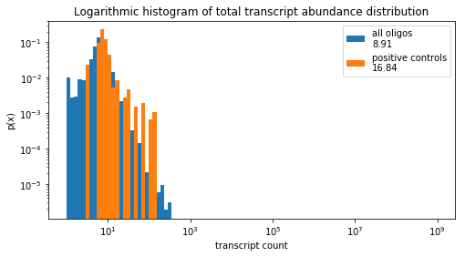

```python
f, subs = plt.subplots(1,1)
f.set_size_inches(8,4)

s = subs
s.loglog()
positive_control_oligos =  oligos.loc[oligos.RefSeqID.isin(positive_controls.Name)]
bins = np.logspace(0,np.log(8000),100)
s.hist(oligos.mu, density=True, bins = bins, label=f"all oligos\n{oligos.mu.mean():.2f}")
s.hist(positive_control_oligos.mu, density=True, bins = bins, label=f"positive controls\n{positive_control_oligos.mu.mean():.2f}")
s.set_title("Logarithmic histogram of total transcript abundance distribution")
s.set_xlabel("transcript count")
s.set_ylabel("p(x)")
s.legend()


print(f"""A: Yes -- positive control oligos exhibit a mean expression rate of {positive_control_oligos.mu.mean():.2f}
unique transcripts observed per unique barcoded oligo) vs {oligos.mu.mean():.2f} for all oligos.""")
```

### Q: Looking at positive control oligo positions, do we find systematically less expression for mutated variants?

```
A: Yes! Mean expression rate (μ) of mutated positive control oligo positions is 14.7, a drop of 29.5%
from the wildtype expression rate: 20.9. This pattern is not overall consistent looking at the full set of ~10k oligos, where
mean mutant μ is 8.9 versus mean μ=9.1 for wildtype oligos.
```

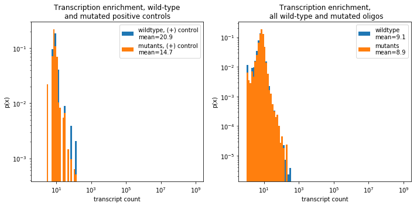

```python
f, subs = plt.subplots(1,2)
f.set_size_inches(10,5)

MEAN_WILDTYPE_PC_MU = wt_controls.mu.mean()
MEAN_MUTANT_PC_MU =mutated_controls.mu.mean()
MEAN_WT_OLIGO_MU = oligos.loc[oligos.mutant_num==0].mu.mean()
MEAN_MUTANT_OLIGO_MU = oligos.loc[oligos.mutant_num!=0].mu.mean()

s = subs[0]
s.loglog()
positive_control_oligos =  oligos.loc[oligos.RefSeqID.isin(positive_controls.Name)]
bins = np.logspace(0,np.log(8000),100)
s.hist(wt_controls.mu, density=True, bins = bins, label=f"wildtype, (+) control\nmean={MEAN_WILDTYPE_PC_MU:.1f}")
s.hist(mutated_controls.mu, density=True, bins = bins, label=f"mutants, (+) control\nmean={MEAN_MUTANT_PC_MU:.1f}")

s.set_title("Transcription enrichment, wild-type\nand mutated positive controls")
s.set_xlabel("transcript count")
s.set_ylabel("p(x)")
s.legend()


s = subs[1]
s.loglog()
positive_control_oligos =  oligos.loc[oligos.RefSeqID.isin(positive_controls.Name)]
bins = np.logspace(0,np.log(8000),100)
s.hist(oligos.loc[oligos.mutant_num!=0].mu, density=True, bins = bins, label=f"wildtype\nmean={MEAN_WT_OLIGO_MU:.1f}")
s.hist(oligos.loc[oligos.mutant_num==0].mu, density=True, bins = bins, label=f"mutants\nmean={MEAN_MUTANT_OLIGO_MU:.1f}")
s.set_title("Transcription enrichment,\n all wild-type and mutated oligos")
s.set_xlabel("transcript count")
s.set_ylabel("p(x)")
s.legend()

plt.tight_layout()

print(f"""A: Yes! Mean expression rate (\u03BC) of mutated positive control oligo positions is {MEAN_MUTANT_PC_MU:.1f}, a drop of {100*(MEAN_WILDTYPE_PC_MU -MEAN_MUTANT_PC_MU) / MEAN_WILDTYPE_PC_MU:.1f}%
from the wildtype expression rate: {MEAN_WILDTYPE_PC_MU:.1f}. This pattern is not overall consistent looking at the full set of ~10k oligos, where
mean mutant \u03BC is {MEAN_MUTANT_OLIGO_MU:.1f} versus mean \u03BC={MEAN_WT_OLIGO_MU:.1f} for wildtype oligos.""")
```

### Q: For positive control oligos, can we identify mutant positions which are more significant than others, using only single oligo loci?

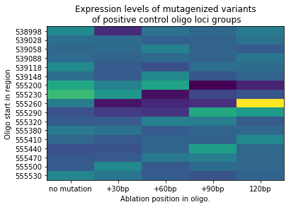

```python
from mpl_toolkits.mplot3d import Axes3D
import matplotlib.pyplot as plt
import pandas as pd
import seaborn as sns

ax0 = plt.gca()

plt.sca(ax0)
pc_loci_oligos = oligos.loc[(oligos.starts.isin(positive_control_positions))]
mutant_pos_grid = pc_loci_oligos[["mu","mutant_num","starts"]].set_index(["starts","mutant_num"]).unstack()["mu"]
mutant_pos_grid = mutant_pos_grid.apply(lambda x: x/ sum(x),axis=1)
ax0.imshow(mutant_pos_grid,aspect="auto")


ax0.set_title("Expression levels of mutagenized variants\n of positive control oligo loci groups")
ax0.set_xlabel("Mutation location")
ax0.set_yticks(range(len(mutant_pos_grid)))
ax0.set_yticklabels(mutant_pos_grid.index)
ax0.set_ylabel("Oligo start in region")

ax0.set_xticks(range(5))
ax0.set_xticklabels(["no mutation","+30bp","+60bp","+90bp","120bp"])
ax0.set_xlabel("Ablation position in oligo.")

# plt.figure()
# ax1 = plt.gca(projection="3d")
# ax1.plot_trisurf(pc_loci_oligos["starts"],pc_loci_oligos["mutant_num"],pc_loci_oligos["mu"], cmap=plt.cm.viridis, linewidth=0.2)
# ax1.set_title("Expression levels of mutagenized variants\n of positive control oligo loci groups")
# ax1.set_xlabel("Ablation position in oligo.")
# plt.tight_layout()
```

### Q: looking at all tiled portions of the 600k bp region, do we see broad peaks of differential transcription?

```
A: Absolutely. There are a number of peaks in the data which now require no obvious smoothing to see.
```

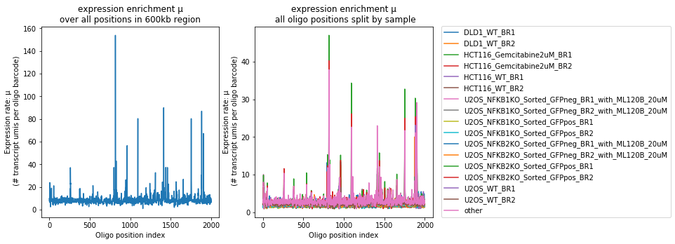

```python
f,subs = plt.subplots(1,2)
f.set_size_inches(10,5)

plt.sca(subs[0])
plt.plot(oligos.groupby("start_index").mu.mean().iloc[::1])
ax = plt.gca()
ax.set_title("expression enrichment \u03BC\nover all positions in 600kb region")
ax.set_ylabel("Expression rate: \u03BC\n (# transcript umis per oligo barcode)")
ax.set_xlabel("Oligo position index")


plt.sca(subs[1])
for k,g in oligos_by_exp.groupby("exp"):
    plt.plot(g.groupby("start_index").mu.mean(),label=k)

ax = plt.gca()
plt.legend(loc=[1.05,0])
ax.set_title("expression enrichment \u03BC\n all oligo positions split by sample")
ax.set_ylabel("Expression rate: \u03BC\n (# transcript umis per oligo barcode)")
ax.set_xlabel("Oligo position index")

print(f"""A: Absolutely. There are a number of peaks in the data which now require no obvious smoothing to see.""")
```

### Q: Sorting by mean expression, can we choose a consistent transcription peak definition without smoothing to reduce noise with local context?

... First approach: sort all oligos in the above figureby mean transcription level. Results shown below.

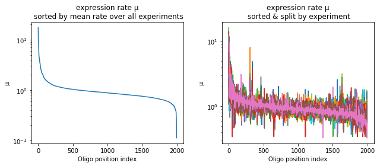

```python
f,subs = plt.subplots(1,2)
f.set_size_inches(9,4)


xvals = starts_by_mean_expression.index

plt.sca(subs[0])
yvals0 = starts_by_mean_expression / np.mean(starts_by_mean_expression)
plt.plot(range(len(yvals0)),yvals0)


ax = plt.gca()
ax.set_title("expression rate \u03BC\n sorted by mean rate over all experiments")
ax.set_ylabel("\u03BC")
ax.set_xlabel("Oligo position index")
ax.set_yscale("log")

plt.sca(subs[1])
for k,g in oligos_by_exp.groupby("exp"):
    yvals = g.groupby("start_index").mu.mean().loc[xvals]
    plt.plot(range(len(yvals)),yvals / np.mean(yvals))



ax = plt.gca()
ax.set_title("expression rate \u03BC\n sorted & split by experiment")
ax.set_ylabel("\u03BC")
ax.set_xlabel("Oligo position index")

ax.set_yscale("log")
plt.tight_layout()
```

For a more useful look, compute a histogram and split into 5% and .5% expression outlier populations. These are labeled "high" and "moderate" expression groups, and used below

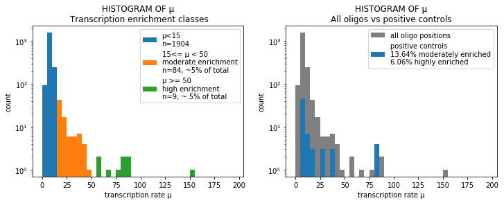

```python
f,subs = plt.subplots(1,2)
f.set_size_inches(12,4)

plt.sca(subs[0])
bins = range(0,200,5)
plt.gca().set_yscale("log")


plt.hist(starts_by_mean_expression,bins = bins, label =f"\u03BC<15\nn={len(low_transcribed_starts)}")

plt.hist(starts_by_mean_expression.loc[starts_by_mean_expression>=15],bins = bins,
         label=f"15<= \u03BC < 50\nmoderate enrichment\nn={len(moderately_transcribed_starts)}, ~5% of total")
plt.hist(starts_by_mean_expression.loc[starts_by_mean_expression>=50],bins = bins,
         label=f"\u03BC >= 50\nhigh enrichment\nn={len(high_transcribed_starts)}, ~.5% of total")


plt.legend()
ax = plt.gca()
ax.set_xlabel("transcription rate \u03BC")
ax.set_ylabel("count")
ax.set_title("HISTOGRAM OF \u03BC\n Transcription enrichment classes")


npos = len(positive_control_oligos)
npos_mod = len(positive_control_oligos.start_index.loc[positive_control_oligos.start_index.isin(moderately_transcribed_starts.index)])
npos_high= len(positive_control_oligos.start_index.loc[positive_control_oligos.start_index.isin(high_transcribed_starts.index)])

plt.sca(subs[1])
ax = plt.gca()
ax.set_xlabel("transcription rate \u03BC")
ax.set_ylabel("count")
ax.set_yscale("log")
ax.set_title("HISTOGRAM OF \u03BC\nAll oligos vs positive controls")
plt.hist(starts_by_mean_expression,bins = bins,color="gray", label =f"all oligo positions")
plt.hist(starts_by_mean_expression.loc[positive_control_oligos.start_index],bins = bins,
         label=f"positive controls\n{npos_mod/npos*100:.2f}% moderately enriched\n{npos_high/npos*100:.2f}% highly enriched")
ax.legend()
```

### Q: Do highly and moderately expressed oligos show varying patterns of expression across replicates in different samples?

... Seems so. We need to look into this further, but looking at both highly and moderately expressed oligo groups, we see that replicates covary, and different experiments are marked by different expression levels.

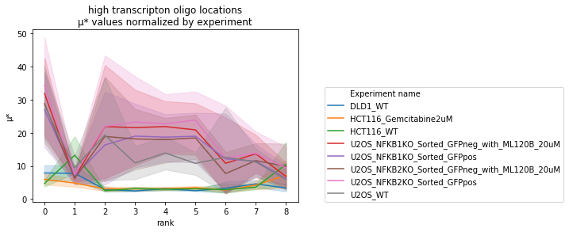

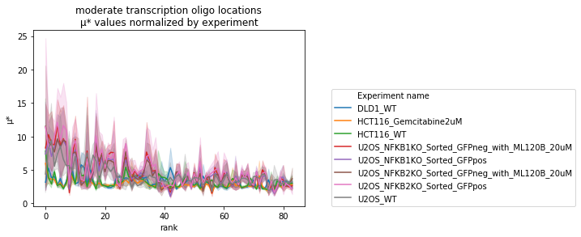

```python
#f,subs = plt.subplots(2,1)


#ax = sns.lineplot(x="start_index", y="mu", hue="exp_nm", data=oligos_by_exp.iloc[::100])

for k,start_set in {"high transcripton":high_transcribed_starts,
                  "moderate transcription":moderately_transcribed_starts}.items():
    plt.figure()
    data = oligos_by_exp.loc[oligos_by_exp.start_index.isin(start_set.index)]\
        .rename({"exp_nm":"Experiment name","exp_norm_mu":"\u03BC*"},axis="columns")
    fake_indices = start_set.reset_index()[["start_index"]].reset_index().set_index("start_index")
    data[["rank"]] = data.start_index.apply(lambda x: fake_indices.loc[x])
    ax = sns.lineplot(x="rank", y="\u03BC*", hue="Experiment name",
                      data=data)
    ax.set_title(f"{k} oligo locations\n\u03BC* values normalized by experiment")
    ax.legend(loc=[1.1,0])
```

### Q: Do ablations have an effect on expression levels for highly-expressed and moderately expressed oligos?

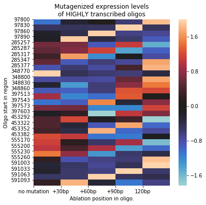

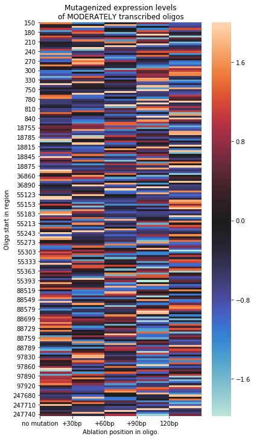

```python
from mpl_toolkits.mplot3d import Axes3D
import matplotlib.pyplot as plt
import pandas as pd
import seaborn as sns

f = plt.gcf()
f.set_size_inches(6,6)
ax0 = plt.gca()

plt.sca(ax0)
pc_loci_oligos = oligos.loc[(oligos.starts.isin(high_transcribed_start_neighborhoods))]
mutant_pos_grid = pc_loci_oligos[["mu","mutant_num","starts"]].set_index(["starts","mutant_num"]).unstack()["mu"][[0,1,2,3,4]].fillna(0)
mutant_pos_grid = mutant_pos_grid.apply(lambda x: (x-np.mean(x))/ np.std(x),axis=1)
sns.heatmap(mutant_pos_grid,center=0)

ax0.set_title("Mutagenized expression levels\nof HIGHLY transcribed oligos")
ax0.set_xlabel("Mutation location")
ax0.set_yticks(range(len(mutant_pos_grid)))
ax0.set_yticklabels(mutant_pos_grid.index)
ax0.set_ylabel("Oligo start in region")

ax0.set_xticks(range(5))
ax0.set_xticklabels(["no mutation","+30bp","+60bp","+90bp","120bp"])
ax0.set_xlabel("Ablation position in oligo.")

plt.figure()
f = plt.gcf()
f.set_size_inches(6,12)
ax0 = plt.gca()

plt.sca(ax0)
pc_loci_oligos = oligos.loc[(oligos.starts.isin(mid_transcribed_start_neighborhoods))]
mutant_pos_grid = pc_loci_oligos[["mu","mutant_num","starts"]].set_index(["starts","mutant_num"]).unstack()["mu"][[0,1,2,3,4]].fillna(0)
mutant_pos_grid = mutant_pos_grid.apply(lambda x: (x-np.mean(x))/ np.std(x),axis=1)
sns.heatmap(mutant_pos_grid,center=0)

ax0.set_title("Mutagenized expression levels\nof MODERATELY transcribed oligos")
ax0.set_xlabel("Mutation location")
ax0.set_yticks(range(0,len(mutant_pos_grid),5))
ax0.set_yticklabels(mutant_pos_grid.index)
ax0.set_ylabel("Oligo start in region")


ax0.set_xticks(range(5))
ax0.set_xticklabels(["no mutation","+30bp","+60bp","+90bp","120bp"])
ax0.set_xlabel("Ablation position in oligo.")
```

## NEXT STEPS

```python
print(f"""A total of {oligos.n_bcs.sum()} barcodes, labeling genomically-inserted oligos are identified, corresponding
to on average {oligos.n_bcs.mean():.2f} barcodes per oligo sequence. Likewise, a total of {oligos.n_transcripts.sum()}
are observed, corresponding to {oligos.n_transcripts.mean():.2f} unique transcript UMIs observed per oligo, or on average
{oligos.n_transcripts.mean()/oligos.n_bcs.mean():.2f}  transcript UMIs per observed barcode """)
```

[output not shown]